# Estudo Dirigido 1 - Modelo Cinematico baseado em Odometria

### Por Caléo Meneses Santos

# Dimensões do Robô Pioneer

[figure not shown]

$$ Diâmetro Roda = D = {195 \over 1000} m \\ Raio = r_d = r_e = {D \over 2} \\ Distância (RodaAoEixo) = L = {381 \over 2*1000 } $$

Importando bibliotecas e classes

- 'Numpy' para cálculos matemáticos
- 'Matplotlib' para desenhar gráficos
- 'RobotPioneer classe-pai' própria criada contendo métodos e propriedades do Robô
- 'RoboPionnerModeloUm' classe-filha contendo o primeiro modelo cinemático do estudo dirigido
- 'RoboPionnerModeloDois' classe-filha contendo o segundo modelo cinemático do estudo dirigido
- 'Simula' é uma função contendo a comunicação com o CoppeliaRobotics
- 'plotaGrafico' é uma função pré construída para comparar as trajetórias dos robôs

```python
import numpy as np
import matplotlib.pyplot as plt
from RoboPionner import RoboPionner, Simula, plotaGrafico
from RoboPionnerModeloUm import RoboPionnerModeloUm
from RoboPionnerModeloDois import RoboPionnerModeloDois
```

Periodo de amostragem e tempo de simulação

```python
Passo = 0.05 # Tempo de passo em segundos
TempoSimulacaoSegundos = 10
t = np.arange(0,TempoSimulacaoSegundos,Passo)
NumeroIteracoes = len(t)
```

## Modelo Cinemático I

$$ \begin{bmatrix} X' \\ Y' \\ \theta' \end{bmatrix} = \begin{bmatrix} cos(\theta) & -sin(\theta) & 0\\ sin(\theta) & cos(\theta) & 0\\ 0 & 0 & 1 \end{bmatrix} \begin{bmatrix} 1 & 0\\ 0 & 0\\ 0 & 1 \end{bmatrix} \begin{bmatrix} r_d/2 & r_e/2\\ r_d/2l & -r_e/2l \end{bmatrix} \begin{bmatrix} \omega_d\\ \omega_r \end{bmatrix} $$

E através da integração:

$$ \begin{bmatrix} X(k+1) \\ Y(k+1) \\ \theta(k+1) \end{bmatrix} = \begin{bmatrix} X(k) \\ Y(k) \\ \theta(k) \end{bmatrix} + \begin{bmatrix} X' \\ Y' \\ \theta' \end{bmatrix} * \delta t $$

## Para velocidades angulares Wd = We = 1

```
Connected to remote API server
Simulando 99.49748743718592%
Simulation Stopped
Simulation Closed
```

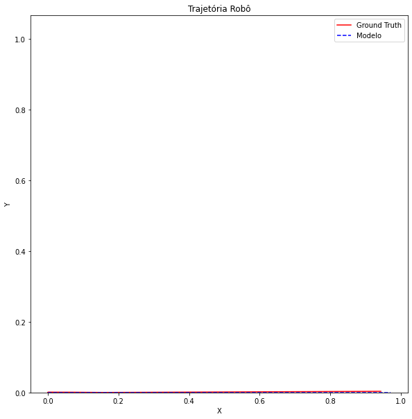

```python
velocidadeAngularRodaDireita = 1
velocidadeAngularRodaEsquerda = 1

#Simulação no Coppelia Robotics
PosicaoRealHistorico = Simula(velocidadeAngularRodaDireita,
                                velocidadeAngularRodaEsquerda,
                                Passo=0.05,
                                TempoSimulacaoSegundos=TempoSimulacaoSegundos)


# Calculo do Modelo I
roboUm = RoboPionnerModeloUm()
PosicaoRoboHistorico = roboUm.posicaoRobo


for i in range(0,NumeroIteracoes-1):
    roboUm.velocidadeAngularRodas = [velocidadeAngularRodaDireita,velocidadeAngularRodaEsquerda]
    PosicaoNova = roboUm.calculaNovaPosicaoRobo(Passo=0.05)
    PosicaoRoboHistorico = np.append(PosicaoRoboHistorico,PosicaoNova,axis=1)

# Desenhando Gráficos
plt.rcParams["figure.figsize"] = (10,10)
plotaGrafico(PosicaoRoboHistorico,PosicaoRealHistorico)
```

## Para velocidades angulares Wd = 0, We = 1

```
Connected to remote API server
Simulando 99.49748743718592%
Simulation Stopped
Simulation Closed
```

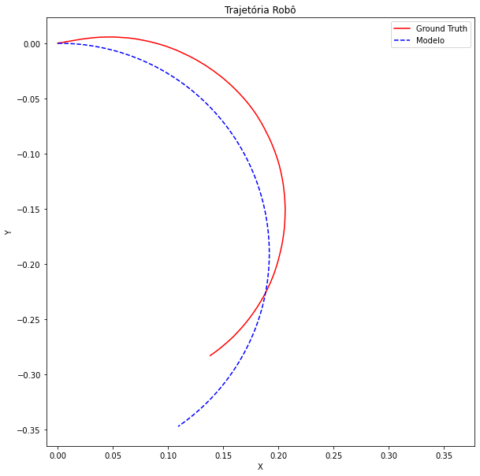

```python
velocidadeAngularRodaDireita = 0
velocidadeAngularRodaEsquerda = 1

#Simulação no Coppelia Robotics
PosicaoRealHistorico = Simula(velocidadeAngularRodaDireita,
                                velocidadeAngularRodaEsquerda,
                                Passo=0.05,
                                TempoSimulacaoSegundos=TempoSimulacaoSegundos)


# Calculo do Modelo I
roboUm = RoboPionnerModeloUm()
PosicaoRoboHistorico = roboUm.posicaoRobo


for i in range(0,NumeroIteracoes-1):
    roboUm.velocidadeAngularRodas = [velocidadeAngularRodaDireita,velocidadeAngularRodaEsquerda]
    PosicaoNova = roboUm.calculaNovaPosicaoRobo(Passo=0.05)
    PosicaoRoboHistorico = np.append(PosicaoRoboHistorico,PosicaoNova,axis=1)

# Desenhando Gráficos
plt.rcParams["figure.figsize"] = (10,10)
plotaGrafico(PosicaoRoboHistorico,PosicaoRealHistorico)
```

## Para velocidades angulares Wd = 1, We = 1.5

```
Connected to remote API server
Simulando 99.49748743718592%
Simulation Stopped
Simulation Closed
```

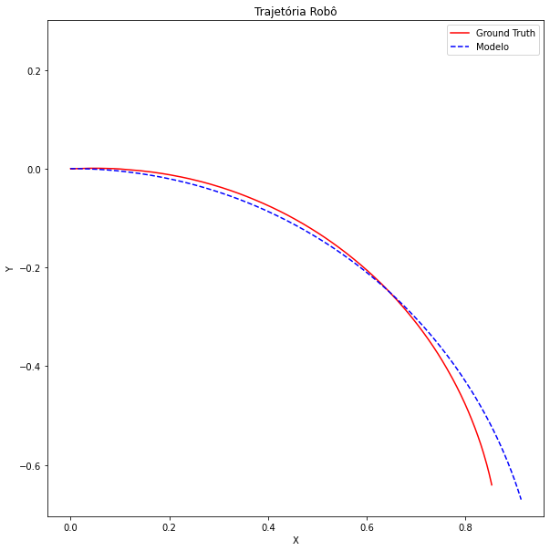

```python
velocidadeAngularRodaDireita = 1
velocidadeAngularRodaEsquerda = 1.5

#Simulação no Coppelia Robotics
PosicaoRealHistorico = Simula(velocidadeAngularRodaDireita,
                                velocidadeAngularRodaEsquerda,
                                Passo=0.05,
                                TempoSimulacaoSegundos=TempoSimulacaoSegundos)


# Calculo do Modelo I
roboUm = RoboPionnerModeloUm()
PosicaoRoboHistorico = roboUm.posicaoRobo


for i in range(0,NumeroIteracoes-1):
    roboUm.velocidadeAngularRodas = [velocidadeAngularRodaDireita,velocidadeAngularRodaEsquerda]
    PosicaoNova = roboUm.calculaNovaPosicaoRobo(Passo=0.05)
    PosicaoRoboHistorico = np.append(PosicaoRoboHistorico,PosicaoNova,axis=1)

# Desenhando Gráficos
plt.rcParams["figure.figsize"] = (10,10)
plotaGrafico(PosicaoRoboHistorico,PosicaoRealHistorico)
```

## Modelo Cinemático II

[figure not shown]

$$ R = {L \over 2} * {v_e + v_d \over v_e - v_d } \\ \omega = {v_e - v_d \over L} \\ ICC = \begin{bmatrix} ICC_x \\ ICC_y \\ \end{bmatrix} = \begin{bmatrix} X - Rsin(\theta) \\ Y + Rcos(\theta) \end{bmatrix} \\ \begin{bmatrix} X(k+1) \\ Y(k+1) \\ \theta(k+1) \end{bmatrix} = \begin{bmatrix} cos(\omega \delta t) & -sin(\omega \delta t) & 0\\ sin(\omega \delta t) & cos(\omega \delta t) & 0\\ 0 & 0 & 1 \end{bmatrix} \begin{bmatrix} X(k) - ICC_x \\ Y(k) - ICC_y \\ \theta(k) \end{bmatrix} + \begin{bmatrix} ICC_x \\ ICC_y \\ \omega \delta t \end{bmatrix} $$

```python
#Periodo de amostragem e tempo de simulacao
Passo = 0.05 # Tempo de passo.
TempoSimulacaoSegundos = 10
t = np.arange(0,TempoSimulacaoSegundos,Passo)
NumeroIteracoes = len(t)
```

## Para velocidades angulares Wd = We = 1

```
Connected to remote API server
Simulando 99.49748743718592%
Simulation Stopped
Simulation Closed
```

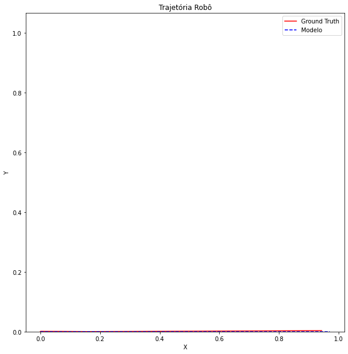

```python
velocidadeAngularRodaDireita = 1
velocidadeAngularRodaEsquerda = 1

#Simulação no Coppelia Robotics
PosicaoRealHistorico = Simula(velocidadeAngularRodaDireita,
                                velocidadeAngularRodaEsquerda,
                                Passo=0.05,
                                TempoSimulacaoSegundos=TempoSimulacaoSegundos)


# Calculo do Modelo II
roboDois = RoboPionnerModeloDois()
PosicaoRoboHistorico = roboDois.posicaoRobo


for i in range(0,NumeroIteracoes-1):
    roboDois.velocidadeAngularRodas = [velocidadeAngularRodaDireita,velocidadeAngularRodaEsquerda]
    PosicaoNova = roboDois.calculaNovaPosicaoRobo(Passo=0.05)
    PosicaoRoboHistorico = np.append(PosicaoRoboHistorico,PosicaoNova,axis=1)

# Desenhando Gráficos
plt.rcParams["figure.figsize"] = (10,10)
plotaGrafico(PosicaoRoboHistorico,PosicaoRealHistorico)
```

## Para velocidades angulares Wd = 1, We = 0

```
Connected to remote API server
Simulando 99.49748743718592%
Simulation Stopped
Simulation Closed
```

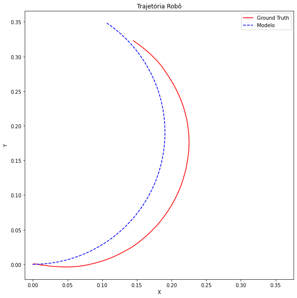

```python
velocidadeAngularRodaDireita = 1
velocidadeAngularRodaEsquerda = 0

#Simulação no Coppelia Robotics
PosicaoRealHistorico = Simula(velocidadeAngularRodaDireita,
                                velocidadeAngularRodaEsquerda,
                                Passo=0.05,
                                TempoSimulacaoSegundos=TempoSimulacaoSegundos)


# Calculo do Modelo II
roboDois = RoboPionnerModeloDois()
PosicaoRoboHistorico = roboDois.posicaoRobo


for i in range(0,NumeroIteracoes-1):
    roboDois.velocidadeAngularRodas = [velocidadeAngularRodaDireita,velocidadeAngularRodaEsquerda]
    PosicaoNova = roboDois.calculaNovaPosicaoRobo(Passo=0.05)
    PosicaoRoboHistorico = np.append(PosicaoRoboHistorico,PosicaoNova,axis=1)

# Desenhando Gráficos
plt.rcParams["figure.figsize"] = (10,10)
plotaGrafico(PosicaoRoboHistorico,PosicaoRealHistorico)
```

## Para velocidades angulares Wd = 2.5, We = 2

```
Connected to remote API server
Simulando 99.49748743718592%
Simulation Stopped
Simulation Closed
```

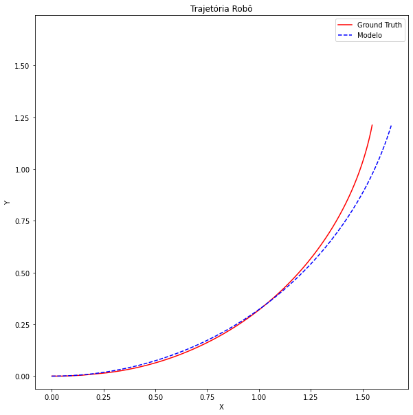

```python
velocidadeAngularRodaDireita = 2.5
velocidadeAngularRodaEsquerda = 2

#Simulação no Coppelia Robotics
PosicaoRealHistorico = Simula(velocidadeAngularRodaDireita,
                                velocidadeAngularRodaEsquerda,
                                Passo=0.05,
                                TempoSimulacaoSegundos=TempoSimulacaoSegundos)


# Calculo do Modelo II
roboDois = RoboPionnerModeloDois()
PosicaoRoboHistorico = roboDois.posicaoRobo


for i in range(0,NumeroIteracoes-1):
    roboDois.velocidadeAngularRodas = [velocidadeAngularRodaDireita,velocidadeAngularRodaEsquerda]
    PosicaoNova = roboDois.calculaNovaPosicaoRobo(Passo=0.05)
    PosicaoRoboHistorico = np.append(PosicaoRoboHistorico,PosicaoNova,axis=1)

# Desenhando Gráficos
plt.rcParams["figure.figsize"] = (10,10)
plotaGrafico(PosicaoRoboHistorico,PosicaoRealHistorico)
```

# Considerações

O Modelo Cinemático I do estudo dirigido é um modelo simples que ajuda dar uma orientação de como as dimensões do robô irão interferir em seu movimento, podendo ser implementado e utilizado rapidamente para uma modelagem inicial.

Em contrapartida, o modelo Cinemático II baseado em odometria pode ser de utilizado como um modelo mais preciso para ao robô Pioneer. Mesmo utilizando somente as equações pré-estabelecidas, o modelo II possui uma leve vantagem na precisão de sua trajetória prevista.

Ambos os modelos nesse estudos possuem erros causados pelas variabilidades de um robô na realidade (nesse caso, o simulador). Questões desprezadas nas equações como derrapagem das rodas, atrito e variabilidade nas velocidades angulares dos motores prejudicam a eficiência dos modelos.

Contudo, o modelo cinemático II possui sua vantagem pela possibilidade ter o encoder óptico incorporado na sua modelagem, deixando mais preciso o cálculo da Velocidade Angular do robô e potencializando a precisão dos modelos.